# Trabalho 04

.

# Séries Temporais

#### Igor Kuivjogi / Kaíque Ferreira / Nilo Célio

#### **4° Trabalho de Séries Temporais**

##### 25 de Agosto de 2020

.

Referências:

- Time Series Analysis (with Applications in R) - Jonathan D. Cryer, Kung-Sik Chan

## Gráfico da série

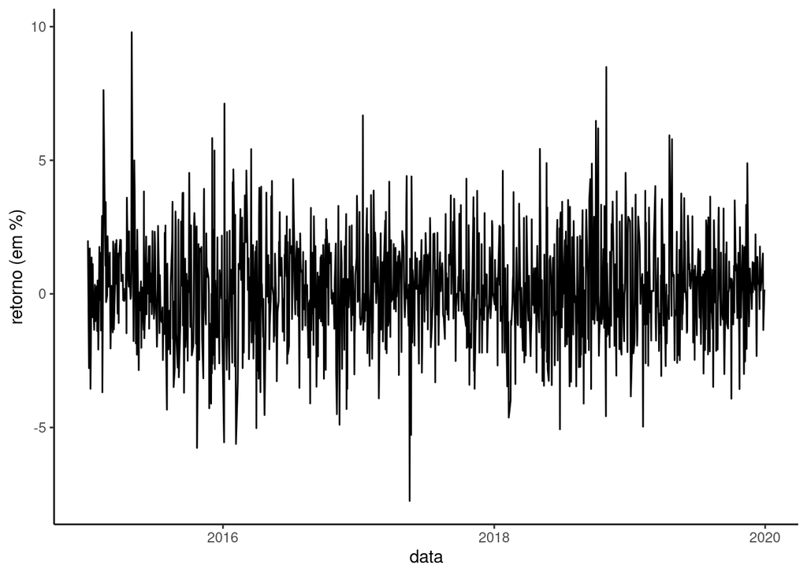

```r
ggplot(renner, aes(x = ref.date, y = ret.adjusted.prices)) +
  geom_line() +
  labs(x = 'data', y = 'retorno (em %)')
```

## ACF

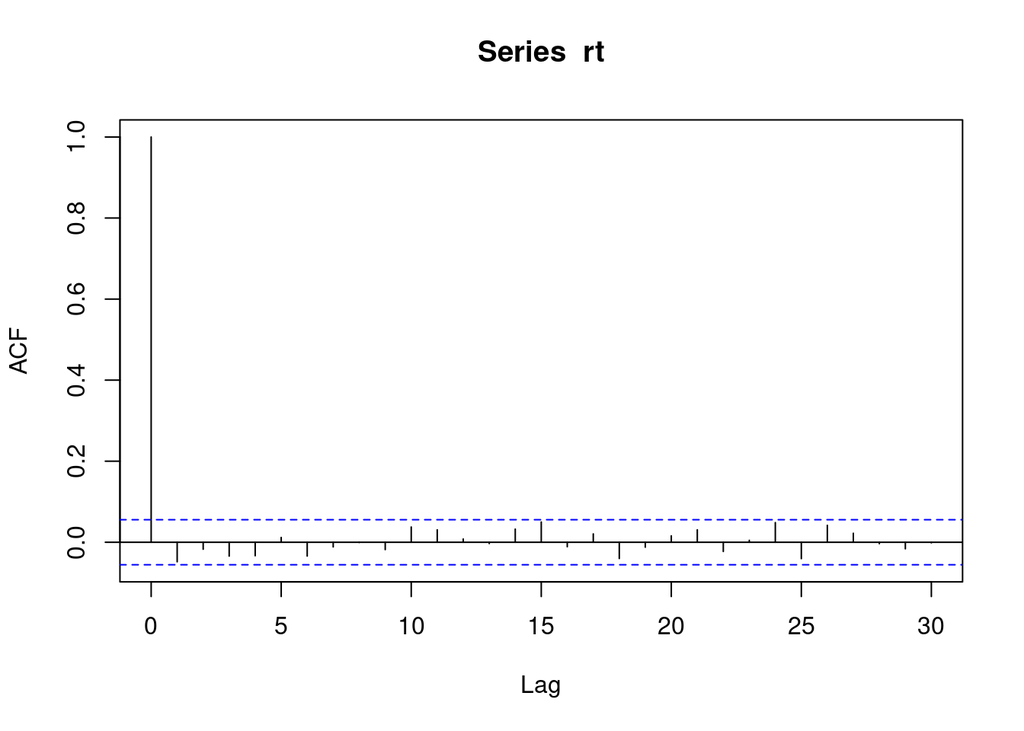

```r
# guardando série de retorno
rt <- renner$ret.adjusted.prices

acf(rt)
```

## PACF

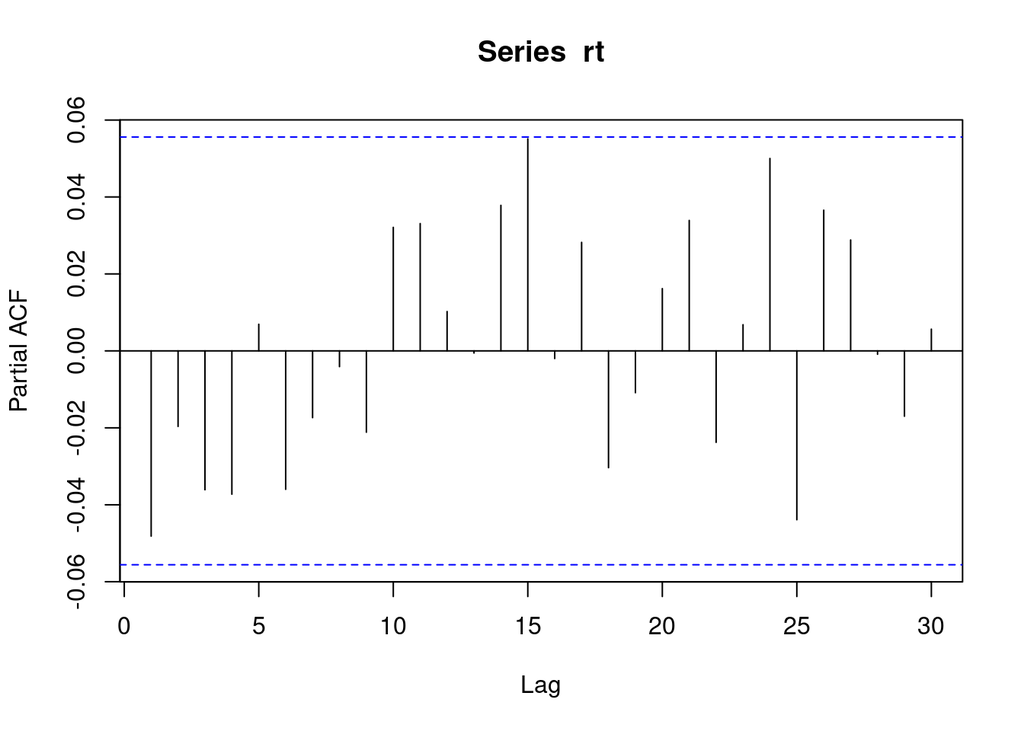

```r
pacf(rt)
```

Os gráficos indicam que a śerie $r_t$ não possui autocorrelação.  
Porém, pelo gráfico da série, podemos ver que a variância não parece ser constante ao longo do tempo, pois em alguns dias seguidos o retorno é muito alto ou muito baixo.  
As séries correlacionadas podem ser estudadas usando o valor absoluto ou o valor quadrático. Se os retornos diários são i.i.d., então os retornos diários em valor absoluto (ou ao quadrado) também serão.

## ACF para valor absoluto e quadrático

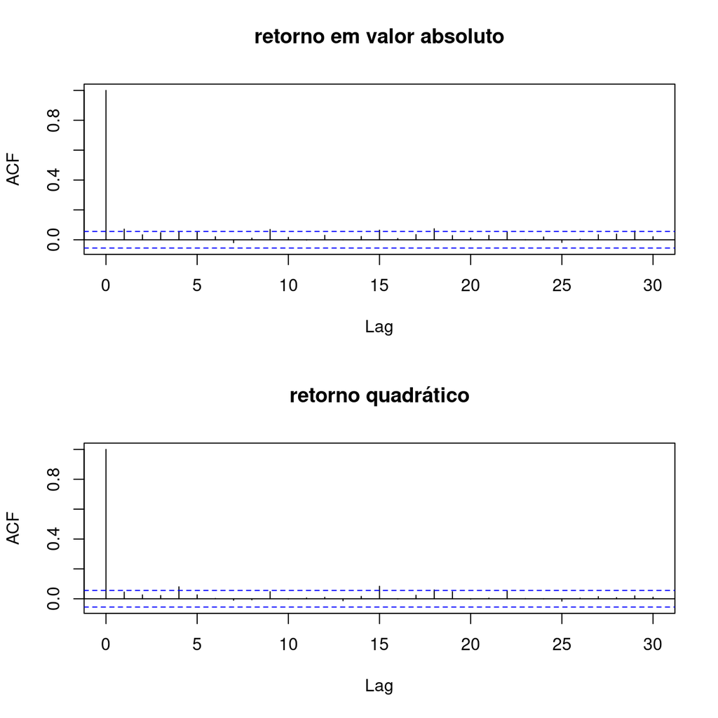

```r
par(mfrow = c(2, 1))
acf(abs(rt), main = 'retorno em valor absoluto')
acf(rt ^ 2, main = 'retorno quadrático')
```

```r
par(mfrow = c(1, 1))
```

## PACF para valor absoluto e quadrático

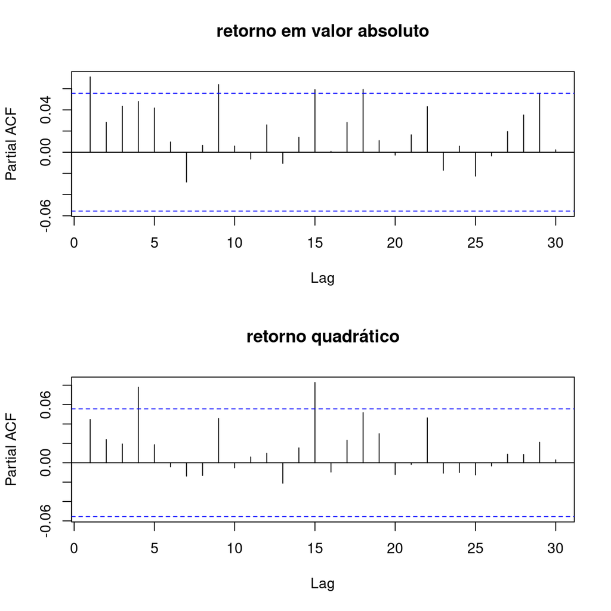

```r
par(mfrow = c(2, 1))
pacf(abs(rt), main = 'retorno em valor absoluto')
pacf(rt ^ 2, main = 'retorno quadrático')
```

```r
par(mfrow = c(1, 1))
```

Como podemos ver, as séries em valor absoluto e ao quadrado possuem autocorrelação, contradizendo a hipótese (para a série original $r_t$) que não existia autocorrelação.

# Modelo ARCH

Os modelos ARCH, ou modelos auto-regressivos com heterocedasticidade condicional, foram introduzidos por Engle (1982), com o objetivo de estimar a variância da inflação. A expectativa aqui é que o retorno $X_t$ seja não-correlacionado serialmente, mas a volatilidade (variância condicional) depende de retornos passados por meio de uma função quadrática.

## Definição

Um modelo $ARCH(p)$ é definido por

$X_t = \sqrt{h_t}\epsilon_t$,

$h_t = \alpha_0 + \alpha_1X_{t-1}^2+\ldots+ \alpha_rX_{t-p}^2$,

onde $\epsilon_t$ é uma sequência de variáveis aleatórias independentes e identicamente distribuídas (i.i.d.) com média zero e variância um, $\alpha_0 > 0$, $\alpha_1 \geq 0$, $i > 0$.

Na prática, usualmente supomos $\epsilon_t$ ~ $N(0,1)$ ou $\epsilon_t$ ~ $t_v$ (distribuição $t$ de Student com $v$ graus de liberdade).

## Propriedades do modelo $ARCH$

$$E(X_t) = 0$$

$$Var(X_t) = \frac{\alpha_0}{1-\alpha_1}$$

$$Cov(X_{t+k}X_t|F_{t+k-1})=0$$

O modelo ARCH na verdade é um modelo de regressão, em que a variável resposta é a volatilidade condicional e os lags passados de $r_t ^ 2$ são as covariáveis.

O modelo $ARCH(1)$ considera somente o retorno quadrático no instante $t$ como função do retorno quadrático anterior, ou seja, $r_{t-1} ^ 2$. Portanto num modelo $ARCH(q)$, considera-se os $t - q$ retornos quadráticos, e não somente o anterior.

# Modelo GARCH

Uma generalização dos modelos $ARCH$ foi sugerida por Bollerslev (1986), chamado modelo $GARCH$ (generalized $ARCH$).

## Definição

Um modelo $GARCH(p,q)$ é definido por

$X_t = \sqrt{h_t}\epsilon_t$,

$h_t = \alpha_0 + \sum_{\substack {i=1}}^{r} \alpha_iX_{\substack {t-i}}^{2} + \sum_{\substack {j=1}}^{s} \beta_jX_{\substack {t-j}}$ ,

em que $\epsilon_t$ i.i.d., $\alpha_0 > 0$, $\alpha_i \geq 0$, $\beta_j \geq 0$, $\sum_{\substack {i=1}}^{q}(\alpha_i + \beta_i) <1$, $r = max(p,q)$.

No modelo $GARCH(p, q)$, além de considerarmos os retornos quadráticos passados, também leva-se em consideração as variâncias condicionais passadas.

## Modelo ARMA para série $r_t$

O modelo $GARCH(p, q)$ para a série original de retornos $r_t$ implica que a série quadrática $r_t ^ 2$ é modelada por um $ARMA(max\{p, q\}, q)$. Então podemos usar todas técnicas de identificação que aprendemos até agora para modelar $r_t^2$ como um modelo $ARMA(p, q)$:

```r
# deixando de fora 10 valores
rt_treino <- rt[1:(length(rt) - 10)]

# ajustando modelo ARMA
mod <- auto.arima(rt_treino ^ 2, d = 0)
summary(mod)
```

```
## Series: rt_treino^2
## ARIMA(1,0,1) with non-zero mean
##
## Coefficients:
##          ar1      ma1    mean
##       0.9838  -0.9677  3.9145
## s.e.  0.0127   0.0174  0.3853
##
## sigma^2 estimated as 47.44:  log likelihood=-4127.46
## AIC=8262.93   AICc=8262.96   BIC=8283.4
##
## Training set error measures:
##                       ME     RMSE      MAE  MPE MAPE      MASE       ACF1
## Training set 0.009930523 6.879247 4.040285 -Inf  Inf 0.7831633 0.01974922
```

O método automático `auto.arima` sugere um $ARMA(1, 1)$ para ajustar o retorno quadrático $r_t ^ 2$.

## Diagnóstico do modelo ARMA, para diferentes lags

```r
checkresiduals(mod, plot = F)
```

```
##
##  Ljung-Box test
##
## data:  Residuals from ARIMA(1,0,1) with non-zero mean
## Q* = 9.3029, df = 7, p-value = 0.2316
##
## Model df: 3.   Total lags used: 10
```

```r
checkresiduals(mod, plot = F, lag = 12)
```

```
##
##  Ljung-Box test
##
## data:  Residuals from ARIMA(1,0,1) with non-zero mean
## Q* = 9.8054, df = 9, p-value = 0.3665
##
## Model df: 3.   Total lags used: 12
```

```r
checkresiduals(mod, plot = F, lag = 16)
```

```
##
##  Ljung-Box test
##
## data:  Residuals from ARIMA(1,0,1) with non-zero mean
## Q* = 17.202, df = 13, p-value = 0.1902
##
## Model df: 3.   Total lags used: 16
```

```r
checkresiduals(mod, plot = F, lag = 20)
```

```
##
##  Ljung-Box test
##
## data:  Residuals from ARIMA(1,0,1) with non-zero mean
## Q* = 21.009, df = 17, p-value = 0.2259
##
## Model df: 3.   Total lags used: 20
```

```r
checkresiduals(mod, plot = F, lag = 24)
```

```
##
##  Ljung-Box test
##
## data:  Residuals from ARIMA(1,0,1) with non-zero mean
## Q* = 23.412, df = 21, p-value = 0.3224
##
## Model df: 3.   Total lags used: 24
```

Para diferentes lags, o teste de Ljung-Box não rejeita a hipótese nula de que os resíduos do modelo $ARMA(1, 1)$ são ruído branco. Através desta identificação, podemos ajustar um $GARCH(1, 1)$.

## Ajustando o modelo GARCH

```r
g_model <- garch(rt_treino, order = c(1, 1), trace = F)
summary(g_model)
```

```
##
## Call:
## garch(x = rt_treino, order = c(1, 1), trace = F)
##
## Model:
## GARCH(1,1)
##
## Residuals:
##      Min       1Q   Median       3Q      Max
## -4.14480 -0.55946  0.02364  0.69758  5.45180
##
## Coefficient(s):
##     Estimate  Std. Error  t value Pr(>|t|)
## a0   0.08554     0.07141    1.198   0.2310
## a1   0.01682     0.00765    2.199   0.0279 *
## b1   0.96151     0.02432   39.541   <2e-16 ***
## ---
## Signif. codes:  0 '***' 0.001 '**' 0.01 '*' 0.05 '.' 0.1 ' ' 1
##
## Diagnostic Tests:
##  Jarque Bera Test
##
## data:  Residuals
## X-squared = 78.439, df = 2, p-value < 2.2e-16
##
##
##  Box-Ljung test
##
## data:  Squared.Residuals
## X-squared = 0.047388, df = 1, p-value = 0.8277
```

## Diagnósticos do modelo

O livro Time Series Analysis (with Applications in R) - Jonathan D. Cryer, Kung-Sik Chan sugere que se o modelo $GARCH(p, q)$, foi escolhido adequadamente, então o valor absoluto, ou quadrado dos resíduos, padronizados do modelo não devem possuir pontos significativos para o gráfico de ACF:

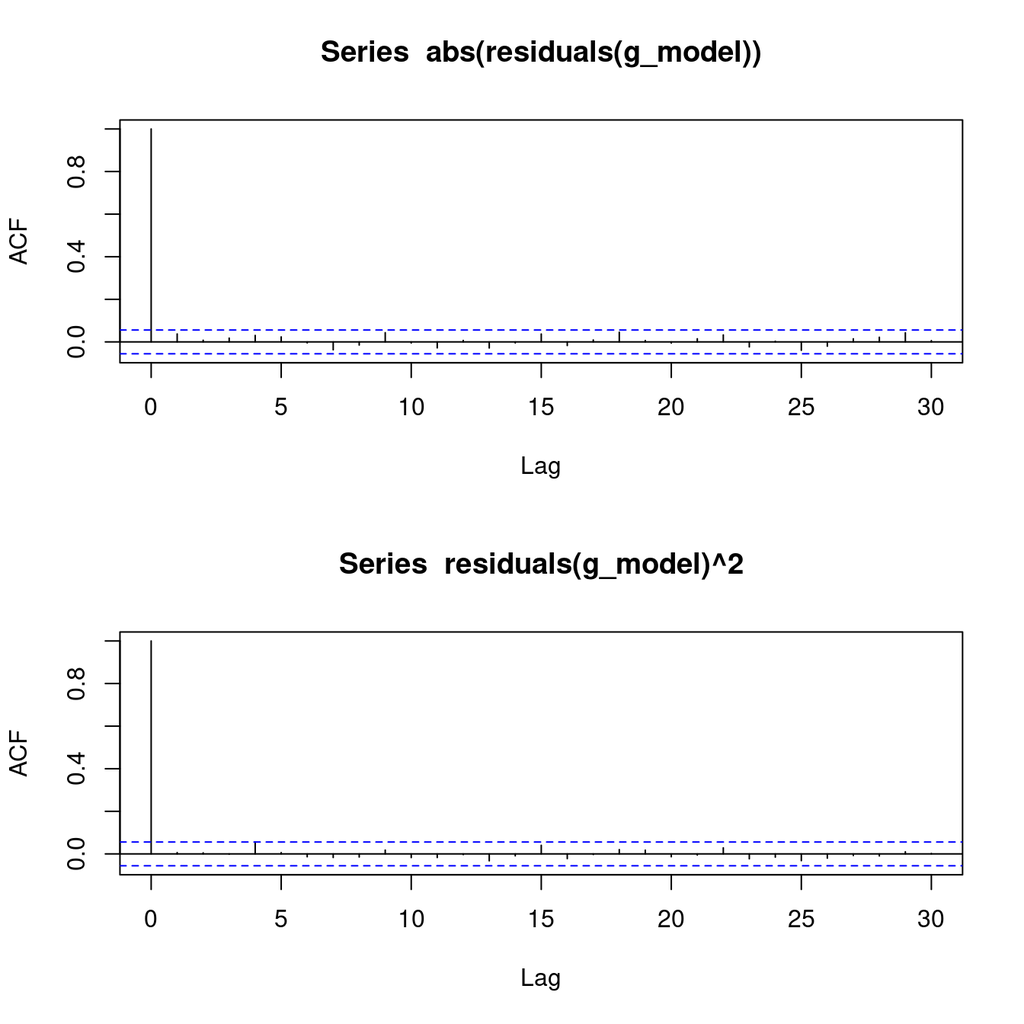

```r
par(mfrow = c(2, 1))
acf(abs(residuals(g_model)), na.action = na.pass)
acf(residuals(g_model) ^ 2, na.action = na.pass)
```

```r
par(mfrow = c(1, 1))
```

Os gráficos sugerem que o modelo $GARCH(1, 1)$ é adequado aos dados de retorno de ações da Renner.

## Função matemática para o modelo $GARCH(1, 1)$:

$X_t = \sqrt{h_t}\epsilon_t$,

$h_t = 0.08554 + \sum_{\substack {i=1}}^{q} 0.01682X_{\substack {t-i}}^{2} + \sum_{\substack {j=1}}^{s} 0.96151X_{\substack {t-j}}$ ,

em que $\epsilon_t$ i.i.d., $q = max(p,q)$.

## Ajustamento do modelo $GARCH(1, 1)$ à série $r_t$

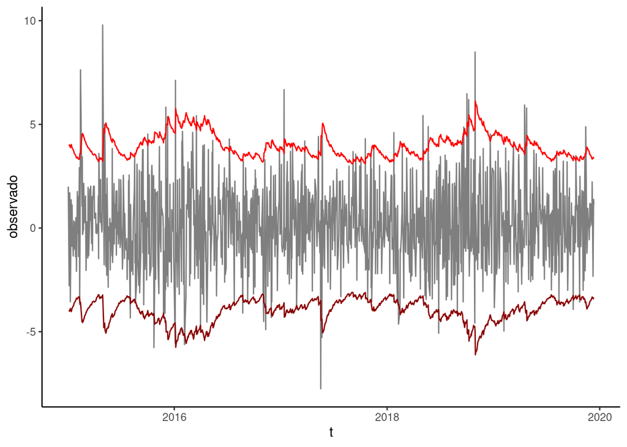

```r
# eleva ao quadrado porque o modelo ajusta o desvio padrão condicional, e não a variância condicional
tibble(t = renner$ref.date[1:1233],
       observado = rt_treino,
       GARCH_pos = fitted(g_model)[, 1] ^ 2,
       GARCH_neg = -fitted(g_model)[, 2] ^ 2) %>%
  ggplot(aes(x = t)) +
  geom_line(aes(y = observado), color = 'grey50') +
  geom_line(aes(y = GARCH_pos), color = 'red') +
  geom_line(aes(y = GARCH_neg), color = 'red4')
```

# Gráfico da predição

A predição retorna o desvio padrão condicional, por isso eleva-se ao quadrado.

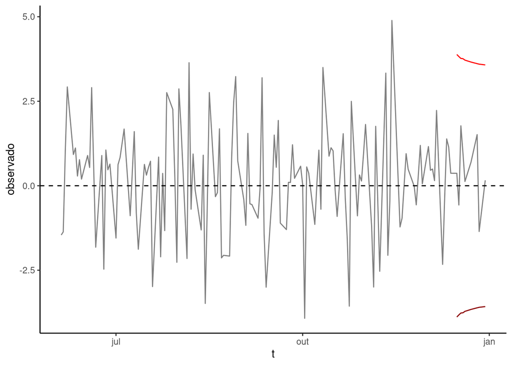

```r
# dados de teste
teste <- rt[1234:1243]
pred <- predict(g_model, newdata = teste)[, 1] ^ 2

tab_pred <- tibble(
  t = renner$ref.date[1:1243],
  observado = rt[1:1243],
  predito_pos = c(rep(NA, 1233), pred),
  predito_neg = c(rep(NA, 1233), -pred)
)

tab_pred[1100:1243, ] %>%
  ggplot(aes(x = t)) +
  geom_line(aes(y = observado), color = 'grey50') +
  geom_line(aes(y = predito_pos), color = 'red') +
  geom_line(aes(y = predito_neg), color = 'red4') +
  geom_hline(yintercept = 0, linetype = 'dashed')
```

## Erro de predição

```r
rmse <- function(y, y_hat) {
  sqrt(sum((y - y_hat) ^ 2) / length(y))
}

cat('RMSE para dados de treino:\n')
```

```
## RMSE para dados de treino:
```

```r
rmse(rt[1235:1243], predict(g_model, newdata = rt[1234:1243])[, 1][2:10])
```

```
## [1] 1.773664
```

```r
cat('RMSE para dados de teste:\n')
```

```
## RMSE para dados de teste:
```

```r
rmse(teste[2:10], pred[2:10])
```

```
## [1] 3.424494
```